# Analysis of periodontal bacteria in relation to disease status and pocket depth

The following notebook performs multidimensional scaling with the bacterial relative abundance data from PerioData.csv The notebook follows the code from: https://environmentalcomputing.net/graphics/multivariate-vis/mds/

```r
library(vegan)
```

```r
library(ggplot2)
```

### Read Data

Make data frame from the periodontal data file PerioData.csv

```r
perio <- read.csv("PerioData.csv")
head(perio)
```

|  | id | strep | prev | lepto | fuso | veil | time | status | pocket | deepest | range |
| --- | --- | --- | --- | --- | --- | --- | --- | --- | --- | --- | --- |
| 1 | S001 | 57.4 | 10.2 | 0.1 | 0.0 | 6.9 | 1 | 2 | 2.7 | 3.8 | middle |
| 2 | S001 | 26.0 | 0.0 | 25.6 | 0.0 | 6.3 | 2 | 2 | 2.7 | 3.0 | middle |
| 3 | S006 | 19.0 | 24.2 | 4.8 | 5.7 | 4.2 | 1 | 1 | 2.5 | 3.2 | middle |
| 4 | S006 | 15.2 | 4.2 | 0.2 | 2.6 | 3.4 | 2 | 1 | 2.4 | 3.2 | middle |
| 5 | S007 | 33.2 | 2.3 | 7.4 | 1.3 | 12.0 | 1 | 2 | 2.4 | 2.7 | shallow |
| 6 | S007 | 18.0 | 0.3 | 13.6 | 1.7 | 13.8 | 2 | 2 | 2.4 | 2.8 | shallow |

Subset the perio data to only have bacterial columns. The next block performs non-metric multidimentional scaling (NMDS) using bray-curtis distances of the bacterial relative abundances. The plot shows all the samples ordinated on this first two axes, MDS1 and MDS2.

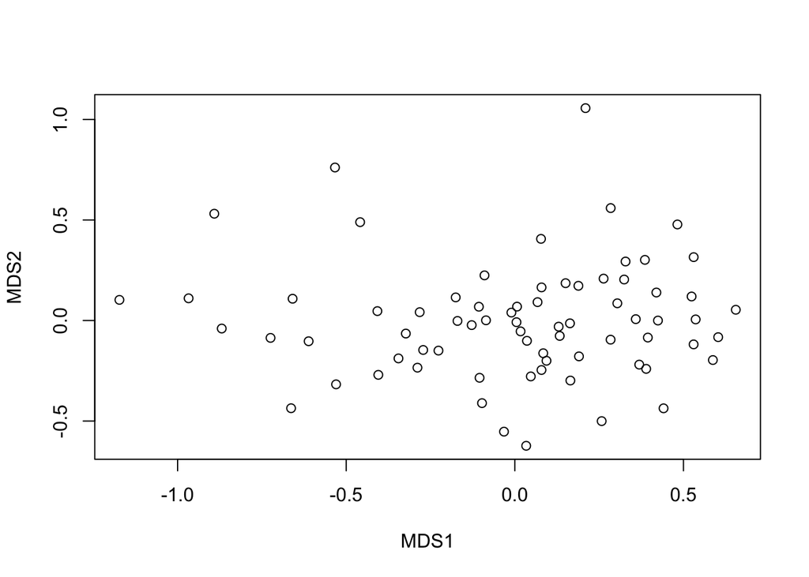

```r
bacteria <- perio[2:6]
#head(bacteria)
bacteria.mds <- metaMDS(comm = bacteria, distance = "bray", trace = FALSE, autotransform = FALSE)
plot(bacteria.mds$points)
```

This block assigns the metadata to the samples in the plot, then the ggplot colors the points in the graph for one variable, in this case disease status.

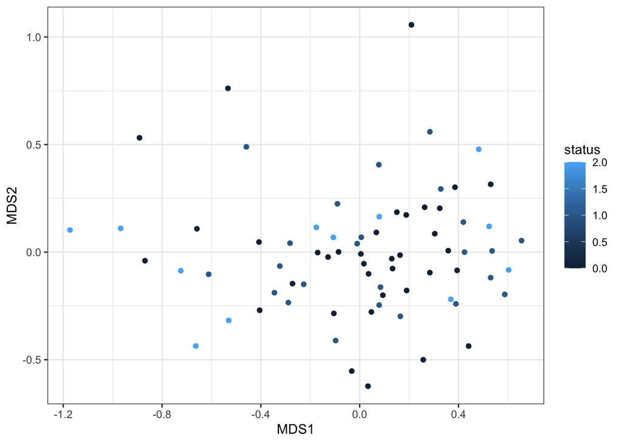

```r
bacteria_xy <- data.frame(bacteria.mds$points)
bacteria_xy$status <- perio$status #disease status 1=not disease; 2=diseased
bacteria_xy$time <- perio$time     #time point
bacteria_xy$range <- perio$range   #range of pocket depth shallow < 3mm, middle 3-3.9, deep 4+

ggplot(bacteria_xy, aes(MDS1, MDS2, color = status)) +
  geom_point() +
  theme_bw()
```

Finally, this block performs a PERMANOVA statistical analysis. This is an ANOVA using distance matrices that uses permutations to ask if the samples group clusters are the same or not. In effect, for this next test, we are asking if there is a difference between the beta diversity of the samples based on disease status.

Here is the full formula for the adnonis2 function that runs the PERMANOVA. By default it performs 999 permutation and uses bray curtis distances. adonis2(formula, data, permutations = 999, method = “bray”, sqrt.dist = FALSE, add = FALSE, by = NULL, parallel = getOption(“mc.cores”), na.action = na.fail, strata = NULL, …)

```r
adonis2(bacteria ~ perio$status) # is there a significant different in the samples base on status?
```

|  | Df | SumOfSqs | R2 | F | Pr(>F) |
| --- | --- | --- | --- | --- | --- |
| Model | 1 | 0.107714 | 0.01632832 | 1.161955 | 0.32 |
| Residual | 70 | 6.489044 | 0.98367168 | NA | NA |
| Total | 71 | 6.596758 | 1.00000000 | NA | NA |

EXERCISE 1: Run the same plots and PERMANOVA using the other two variables: time and range

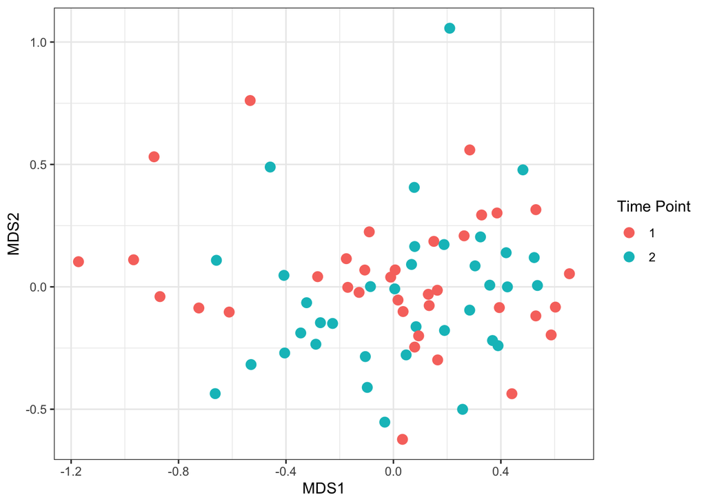

```r
#looks at the time instead of status for the plot
ggplot(bacteria_xy, aes(MDS1, MDS2, color = factor(time))) +
  geom_point(size = 3) +
  theme_bw() +
  labs(color = "Time Point")
```

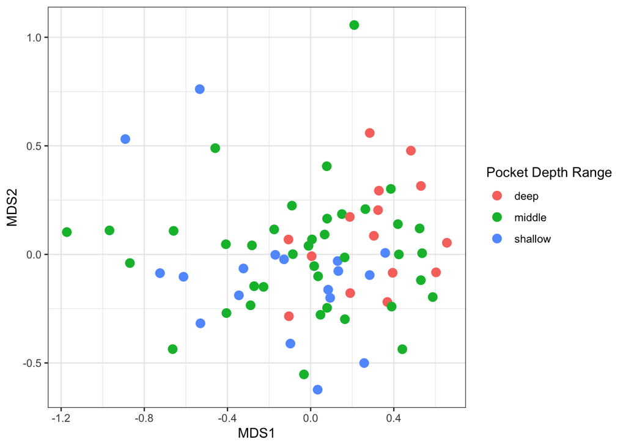

```r
#looks at the range for the plot
ggplot(bacteria_xy, aes(MDS1, MDS2, color = factor(range))) +
  geom_point(size = 3) +
  theme_bw() +
  labs(color = "Pocket Depth Range")
```

Conduct the PERMANOVA test

```r
adonis2(bacteria ~ time, data = perio, method = "bray") #looks at time only
```

|  | Df | SumOfSqs | R2 | F | Pr(>F) |
| --- | --- | --- | --- | --- | --- |
| Model | 1 | 0.156701 | 0.02375424 | 1.703256 | 0.148 |
| Residual | 70 | 6.440057 | 0.97624576 | NA | NA |
| Total | 71 | 6.596758 | 1.00000000 | NA | NA |

```r
adonis2(bacteria ~ range, data = perio, method = "bray") #looks at range only
```

|  | Df | SumOfSqs | R2 | F | Pr(>F) |
| --- | --- | --- | --- | --- | --- |
| Model | 2 | 0.6082271 | 0.09220091 | 3.504004 | 0.006 |
| Residual | 69 | 5.9885307 | 0.90779909 | NA | NA |
| Total | 71 | 6.5967578 | 1.00000000 | NA | NA |

```r
adonis2(bacteria ~ time + range, data = perio, method = "bray") # looks at both time + range
```

|  | Df | SumOfSqs | R2 | F | Pr(>F) |
| --- | --- | --- | --- | --- | --- |
| Model | 3 | 0.7687646 | 0.1165367 | 2.989937 | 0.003 |
| Residual | 68 | 5.8279931 | 0.8834633 | NA | NA |
| Total | 71 | 6.5967578 | 1.0000000 | NA | NA |

EXERCISE 2: REPEAT the analyses above after rclr transformation of the bacteria data.

Step 1) convert to rclr - zeros replaced with minimum values Step 2) run the mds with method=“euclidean” and plot with the same variables Step 3) run the adonis2 with euclidean distances and 9999 permutations

Step 1:

```r
bacteria <- perio[, c("strep", "prev", "lepto", "fuso", "veil")] #pull all the bacteria columns
rclr_transform <- decostand(bacteria, method = "rclr") #robust clr transform
column_names <- c("rclr_strep","rclr_prev","rclr_lepto",
                                     "rclr_fuso", "rclr_veil") #create the column names
colnames(rclr_transform) <- column_names #rename the column names
head(rclr_transform) #check the data
```

|  | rclr_strep | rclr_prev | rclr_lepto | rclr_fuso | rclr_veil |
| --- | --- | --- | --- | --- | --- |
| 1 | 2.2958423 | 0.9002151 | -3.70867554 | -0.53777465 | 1.0503927 |
| 2 | 0.1265209 | -0.2022128 | 0.42273193 | 0.04402795 | -0.3910680 |
| 3 | 0.3776055 | 0.5010599 | -0.82427585 | 0.09216754 | -0.1465571 |
| 4 | 1.4607524 | 0.5868003 | -2.48505303 | -0.38488637 | 0.8223867 |
| 5 | 1.2904492 | -1.5169287 | -0.04532812 | -0.99093589 | 1.2627435 |
| 6 | 1.0801976 | -2.6013040 | 1.18357066 | -1.33434274 | 1.6718784 |

```r
perio <- cbind(perio,rclr_transform) #add rclr_transform to the perio data
head(perio) #check the data
```

|  | id | strep | prev | lepto | fuso | veil | time | status | pocket | deepest | range | rclr_strep | rclr_prev | rclr_lepto | rclr_fuso | rclr_veil |
| --- | --- | --- | --- | --- | --- | --- | --- | --- | --- | --- | --- | --- | --- | --- | --- | --- |
| 1 | S001 | 57.4 | 10.2 | 0.1 | 0.0 | 6.9 | 1 | 2 | 2.7 | 3.8 | middle | 2.2958423 | 0.9002151 | -3.70867554 | -0.53777465 | 1.0503927 |
| 2 | S001 | 26.0 | 0.0 | 25.6 | 0.0 | 6.3 | 2 | 2 | 2.7 | 3.0 | middle | 0.1265209 | -0.2022128 | 0.42273193 | 0.04402795 | -0.3910680 |
| 3 | S006 | 19.0 | 24.2 | 4.8 | 5.7 | 4.2 | 1 | 1 | 2.5 | 3.2 | middle | 0.3776055 | 0.5010599 | -0.82427585 | 0.09216754 | -0.1465571 |
| 4 | S006 | 15.2 | 4.2 | 0.2 | 2.6 | 3.4 | 2 | 1 | 2.4 | 3.2 | middle | 1.4607524 | 0.5868003 | -2.48505303 | -0.38488637 | 0.8223867 |
| 5 | S007 | 33.2 | 2.3 | 7.4 | 1.3 | 12.0 | 1 | 2 | 2.4 | 2.7 | shallow | 1.2904492 | -1.5169287 | -0.04532812 | -0.99093589 | 1.2627435 |
| 6 | S007 | 18.0 | 0.3 | 13.6 | 1.7 | 13.8 | 2 | 2 | 2.4 | 2.8 | shallow | 1.0801976 | -2.6013040 | 1.18357066 | -1.33434274 | 1.6718784 |

Step 2:

```r
rclr_bacteria <- perio[12:16] #select the rclr transformed data

bacteria.mds <- metaMDS(comm = rclr_bacteria, distance = "euclidean", trace = FALSE, autotransform = FALSE)  #calculating the mds with euclidean distance + rclr_bacteria
```

```
## 'comm' has negative data: 'autotransform', 'noshare' and 'wascores' set to FALSE
```

```r
bacteria_xy <- data.frame(bacteria.mds$points)
bacteria_xy$status <- as.factor(perio$status) #disease status 1=not disease; 2=diseased
bacteria_xy$time <- perio$time #time point
bacteria_xy$range <- perio$range #range of pocket depth shallow < 3mm, middle 3-3.9, deep 4+
```

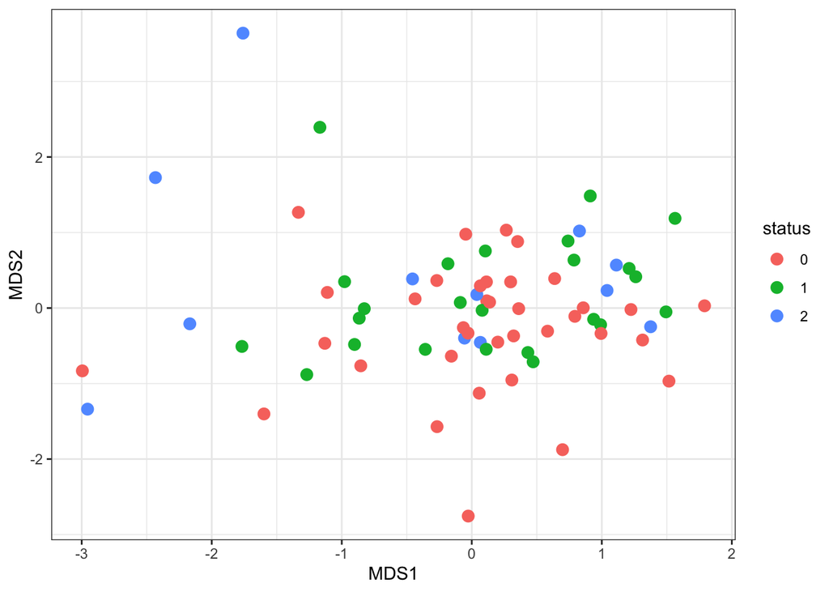

```r
#looks at the status
ggplot(bacteria_xy, aes(x = MDS1, y = MDS2, color = status)) + #assign variables
  geom_point(size = 3) + #create scatter plot
  theme_bw() #denote theme
```

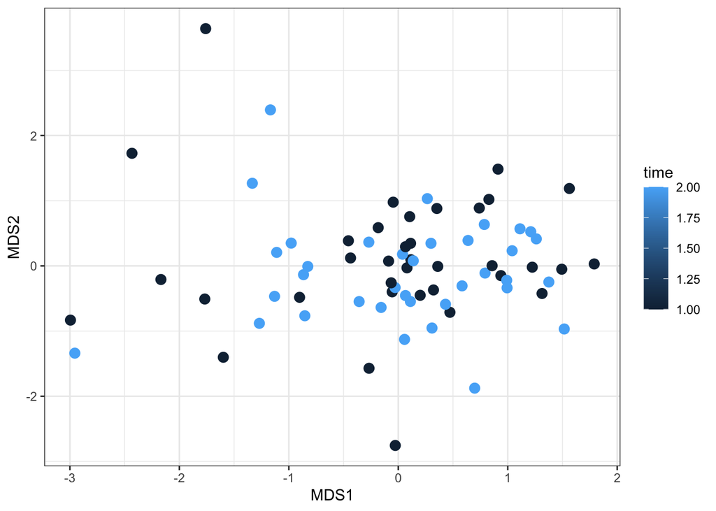

```r
#looks at the time instead of status for the plot
ggplot(bacteria_xy, aes(x = MDS1, y = MDS2, color = time)) + #assign variables
  geom_point(size = 3) + #create scatter plot
  theme_bw() #denote theme
```

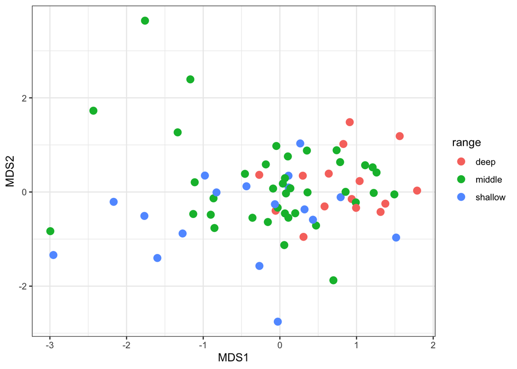

```r
#looks at range instead of status for the plot
ggplot(bacteria_xy, aes(x = MDS1, y = MDS2, color = range)) + #assign variables
  geom_point(size = 3) + #creates the scatter plot
  theme_bw() #denote the theme
```

Step 3:

```r
#create a distance matrix for the PERMANOVA
dist <- dist(rclr_bacteria, method = "euclidean") #use the rclr data

#run the PERMANOVA utilizing euclidean distances and 9999 permutations
adonis2(dist ~ status, data = perio, permutations = 9999) #looking only at status
```

|  | Df | SumOfSqs | R2 | F | Pr(>F) |
| --- | --- | --- | --- | --- | --- |
| Model | 1 | 6.558059 | 0.03162953 | 2.286385 | 0.0838 |
| Residual | 70 | 200.781675 | 0.96837047 | NA | NA |
| Total | 71 | 207.339735 | 1.00000000 | NA | NA |

```r
adonis2(dist ~ time, data = perio, permutations = 9999) #looking only at time
```

|  | Df | SumOfSqs | R2 | F | Pr(>F) |
| --- | --- | --- | --- | --- | --- |
| Model | 1 | 4.363169 | 0.02104357 | 1.504715 | 0.2174 |
| Residual | 70 | 202.976566 | 0.97895643 | NA | NA |
| Total | 71 | 207.339735 | 1.00000000 | NA | NA |

```r
adonis2(dist ~ range, data = perio, permutations = 9999) #looking only at range
```

|  | Df | SumOfSqs | R2 | F | Pr(>F) |
| --- | --- | --- | --- | --- | --- |
| Model | 2 | 24.05221 | 0.1160039 | 4.527321 | 4e-04 |
| Residual | 69 | 183.28752 | 0.8839961 | NA | NA |
| Total | 71 | 207.33973 | 1.0000000 | NA | NA |

```r
adonis2(dist ~ time + range, data = perio, permutations = 9999) #looking at time + range
```

|  | Df | SumOfSqs | R2 | F | Pr(>F) |
| --- | --- | --- | --- | --- | --- |
| Model | 3 | 28.84172 | 0.1391037 | 3.662482 | 4e-04 |
| Residual | 68 | 178.49801 | 0.8608963 | NA | NA |
| Total | 71 | 207.33973 | 1.0000000 | NA | NA |